# Course 2 - Assigment 1

## Run an analysis of variance.

You will need to analyze and interpret post hoc paired comparisons in instances where your original statistical test was significant, and you were examining more than two groups (i.e. more than two levels of a categorical, explanatory variable).

WHAT TO SUBMIT: Following completion of the steps described above, create a blog entry where you submit syntax used to run an ANOVA (copied and pasted from your program) along with corresponding output and a few sentences of interpretation.

```python
%matplotlib inline
import pandas as pd
import numpy as np
import matplotlib.pyplot as plt
import seaborn as sns
import warnings
warnings.filterwarnings('ignore')
```

```
:0: FutureWarning: IPython widgets are experimental and may change in the future.
```

```python
data = pd.read_csv("../e.csv", low_memory=False)
```

# Codes

## S2AQ5B - How often drank beer last 12 months

- 1: Every day
- 2: Nearly every day
- 3: 3 to 4 times a week
- 4: 2 times a week
- 5: Once a week
- 6: 2 to 3 times a month
- 7: Once a month
- 8: 7 to 11 times in the last year
- 9: 3 to 6 times in the last year
- 10: 1 or 2 times in the last year
- 99: Unknown
- BL: NA, did not drink or unknown if drank beer in last 12 months

## S2BQ2E - Number of episodes of alcohol dependence

- 1-98: Number of episodes
- 99: Unknown
- BL: NA, lifetime abstainer; did not meet symptom and/or duration criteria for lifetime alcohol dependence

## S2DQ1 - Blood/natural Father ever an alcoholic or problem drinker

- 1: Yes
- 2: No
- 9: Unknown

## S2DQ2 - Blood/natural Mother ever an alcoholic or problem drinker

- 1: Yes
- 2: No
- 9: Unknown

## S2AQ5D - Number of beers usually consumed on days when drank beer in last 12 months

- 1-42: Number of beers
- 99: Unknown
- BL: NA

## What we'll do?

Make a F-ANOVA test with number of beers usually consumed on days when drank beer with two categorical statistics. First of them with two groups: dependent parent. The other one with a new variable created with the alcohol comsumption frequency and with more than two categories.

```
Number of NAs in S2AQ5D 0
Number of NAs in S2DQ1  0
Number of NAs in S2DQ2  0
Count list for S2AQ5D.
30       2
36       1
6     1049
1     6753
24      22
25       1
20       7
7      112
2     4663
11       6
10     101
13       3
12     208
15      18
14       6
17       4
16       1
18      16
8      191
3     2414
9       27
4     1138
42       1
5      486
dtype: int64
```

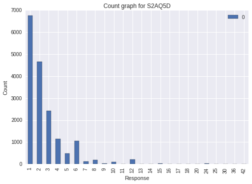

```python
#We don't have NA data
print "Number of NAs in S2AQ5D",
print len(data["S2AQ5D"][data["S2AQ5D"].isnull()])
print "Number of NAs in S2DQ1 ",
print len(data["S2AQ5B"][data["S2DQ1"].isnull()])
print "Number of NAs in S2DQ2 ",
print len(data["S2AQ5B"][data["S2DQ2"].isnull()])

#Discarding the 99 and BL cases
#The BL is displayed as " "
#And unknown cases
sub_data = data[:][(data["S2AQ5D"] != "99") & (data["S2AQ5D"] != " ")]
sub_data = sub_data[:][sub_data["S2DQ1"] != 9]
sub_data = sub_data[:][sub_data["S2DQ2"] != 9]
print "Count list for S2AQ5D."
print sub_data["S2AQ5D"].value_counts(sort=False)

bar = pd.DataFrame(sub_data["S2AQ5D"].convert_objects(convert_numeric=True).value_counts())
bar = bar.sort()
ax = bar.plot(kind='bar')
plt.ylabel("Count")
plt.xlabel("Response")
plt.title('Count graph for S2AQ5D')
plt.show()
```

```python
sub_data["dependent_parent"] = sub_data.apply(lambda x: 1 if x["S2DQ2"]==1 or x["S2DQ1"]==1 else 0 , axis = 1)
print "Count list for Dependent Parent: "
print sub_data["dependent_parent"].value_counts(sort=False)
```

```
Count list for Dependent Parent:
0    12941
1     4289
dtype: int64
```

## The F-ANOVA TEST

So, our question will be: **Do people with one dependent parent consume more alcohol than people without alcohol dependency in parents?**

```python
import statsmodels.formula.api as smf
import statsmodels.stats.multicomp as multi
sub_data["S2AQ5D"] = sub_data["S2AQ5D"].convert_objects(convert_numeric=True)

print "Mean number of beers when drinking for no dependent parent (0) and with dependent parent(1)"
print sub_data[["S2AQ5D", "dependent_parent"]].groupby("dependent_parent").mean()


print "Standard deviation number of beers when drinking for no dependent parent (0) and with dependent parent(1)"
print sub_data[["S2AQ5D", "dependent_parent"]].groupby("dependent_parent").std()


model1 = smf.ols(formula="S2AQ5D ~ C(dependent_parent)", data=sub_data)
results1 = model1.fit()
print results1.summary()
```

```
Mean number of beers when drinking for no dependent parent (0) and with dependent parent(1)
                    S2AQ5D
dependent_parent
0                 2.455838
1                 2.923525
Standard deviation number of beers when drinking for no dependent parent (0) and with dependent parent(1)
                    S2AQ5D
dependent_parent
0                 2.161809
1                 2.817312
                            OLS Regression Results
==============================================================================
Dep. Variable:                 S2AQ5D   R-squared:                       0.007
Model:                            OLS   Adj. R-squared:                  0.007
Method:                 Least Squares   F-statistic:                     128.4
Date:                Sun, 22 May 2016   Prob (F-statistic):           1.14e-29
Time:                        21:57:14   Log-Likelihood:                -39111.
No. Observations:               17230   AIC:                         7.823e+04
Df Residuals:                   17228   BIC:                         7.824e+04
Df Model:                           1
Covariance Type:            nonrobust
============================================================================================
                               coef    std err          t      P>|t|      [95.0% Conf. Int.]
--------------------------------------------------------------------------------------------
Intercept                    2.4558      0.021    119.279      0.000         2.415     2.496
C(dependent_parent)[T.1]     0.4677      0.041     11.333      0.000         0.387     0.549
==============================================================================
Omnibus:                    13782.172   Durbin-Watson:                   1.978
Prob(Omnibus):                  0.000   Jarque-Bera (JB):           463751.948
Skew:                           3.624   Prob(JB):                         0.00
Kurtosis:                      27.360   Cond. No.                         2.49
==============================================================================

Warnings:
[1] Standard Errors assume that the covariance matrix of the errors is correctly specified.
```

# Conclusions

**Null Hypothesis**: People with at least one of their parents with alcohol depedency drink as many beers, in mean, as people with no dependent parents. The F-statistic is 128.4, very high. The p-value associated is 1.14*10^(-29), extremely low. So, we can reject the H0. Thus, we have evidence about the influence of parent's alcoholic problems in their sons.

# Creating new categorical data for multiple analysis!

Now we'll create a new column following what we defined earlier

- 1-3 : High frequency, "high" or just 1
- 4-6 : Mild, or 2;
- 7-10 : Low
- 99 and BL: Discard!

We'll test if number of beers mean is different between the low, mild and high profiles for "S2AQ5B - How often drank beer last 12 months". So, we're investigating if people who drink more frequently drink more too.

```python
sub_data = data[:][(data["S2AQ5D"] != "99") & (data["S2AQ5D"] != " ")]
sub_data = sub_data[:][(sub_data["S2AQ5B"] != "99") & (sub_data["S2AQ5B"] != " ")]

sub_data["S2AQ5D"] = sub_data["S2AQ5D"].convert_objects(convert_numeric=True)


sub_data["alcohol_profile_12m"] = sub_data["S2AQ5B"].apply(lambda x : 1 if int(x) < 4 else 2 if 3 < int(x) < 7 else 3)
print "Count list for our new variable Alcohol Profile last 12 monts!"
print sub_data["alcohol_profile_12m"].value_counts(sort=False)

print "Mean number of beers when drinking for no dependent parent (0) and with dependent parent(1)"
print sub_data[["S2AQ5D", "alcohol_profile_12m"]].groupby("alcohol_profile_12m").mean()


print "Standard deviation number of beers when drinking for no dependent parent (0) and with dependent parent(1)"
print sub_data[["S2AQ5D", "alcohol_profile_12m"]].groupby("alcohol_profile_12m").std()


model1 = smf.ols(formula="S2AQ5D ~ C(alcohol_profile_12m)", data=sub_data)
results1 = model1.fit()
print results1.summary()

mc1 = multi.MultiComparison(sub_data["S2AQ5D"], sub_data["alcohol_profile_12m"])
res1 = mc1.tukeyhsd()
print res1.summary()
```

```
Count list for our new variable Alcohol Profile last 12 monts!
1    3009
2    7224
3    8014
dtype: int64
Mean number of beers when drinking for no dependent parent (0) and with dependent parent(1)
                       S2AQ5D
alcohol_profile_12m
1                    3.747092
2                    3.003599
3                    1.777514
Standard deviation number of beers when drinking for no dependent parent (0) and with dependent parent(1)
                       S2AQ5D
alcohol_profile_12m
1                    3.204081
2                    2.440087
3                    1.504447
                            OLS Regression Results
==============================================================================
Dep. Variable:                 S2AQ5D   R-squared:                       0.103
Model:                            OLS   Adj. R-squared:                  0.103
Method:                 Least Squares   F-statistic:                     1046.
Date:                Sun, 22 May 2016   Prob (F-statistic):               0.00
Time:                        22:14:51   Log-Likelihood:                -40654.
No. Observations:               18247   AIC:                         8.131e+04
Df Residuals:                   18244   BIC:                         8.134e+04
Df Model:                           2
Covariance Type:            nonrobust
===============================================================================================
                                  coef    std err          t      P>|t|      [95.0% Conf. Int.]
-----------------------------------------------------------------------------------------------
Intercept                       3.7471      0.041     91.520      0.000         3.667     3.827
C(alcohol_profile_12m)[T.2]    -0.7435      0.049    -15.258      0.000        -0.839    -0.648
C(alcohol_profile_12m)[T.3]    -1.9696      0.048    -41.018      0.000        -2.064    -1.875
==============================================================================
Omnibus:                    14953.839   Durbin-Watson:                   1.970
Prob(Omnibus):                  0.000   Jarque-Bera (JB):           586772.573
Skew:                           3.704   Prob(JB):                         0.00
Kurtosis:                      29.775   Cond. No.                         5.21
==============================================================================

Warnings:
[1] Standard Errors assume that the covariance matrix of the errors is correctly specified.
Multiple Comparison of Means - Tukey HSD,FWER=0.05
=============================================
group1 group2 meandiff  lower   upper  reject
---------------------------------------------
  1      2    -0.7435  -0.8577 -0.6293  True
  1      3    -1.9696  -2.0821  -1.857  True
  2      3    -1.2261  -1.3115 -1.1407  True
---------------------------------------------
```

# Conclusions

We have now some evidence that people who often drink, drink more too. The F static is very high and the p-value associated is zero. So we reject the H0, that people with different drink frequency habits consume the same amount of beer when they drink.